# Analisis Gerombol / *Cluster Analysis*

**Dhea Dewanti & Nur Khamidah**

## Pendahuluan

Analisis gerombol (*cluster analysis*) adalah sebuah teknik statistik yang digunakan untuk mengelompokkan objek atau data ke dalam kelompok-kelompok (gerombol atau *cluster*) berdasarkan kesamaan karakteristik atau atribut tertentu yang diperoleh dari peubah-peubah penciri yang ada. Tujuan utama dari penggerombolan adalah untuk mengidentifikasi pola atau struktur dalam data yang memungkinkan objek-objek dalam kelompok memiliki kesamaan yang tinggi dan sebaliknya memiliki perbedaan yang tinggi antara kelompok-kelompok yang berbeda.

Konsep dasar dalam penggerombolan adalah mengukur sejauh mana objek-objek dalam data mirip satu sama lain menggunakan dengan ukuran kesamaan atau jarak. Ukuran ini dapat berbeda tergantung pada metode pengelompokan yang digunakan. Jarak antara 2 objek `a` dan `b` dinotasikan dengan `d(a,b)`, di mana:

- Jarak 2 objek yang berbeda tidak mungkin bernilai negatif (`d(a,b)` ≥ 0)
- Jarak 2 objek yang sama bernilai nol (`d(a,a) = 0`)
- Jarak 2 objek bersifat komutatif (`d(a,b) = d(b,a)`)
- Jarak 2 objek berbanding terbalik dengan kemiripannya (semakin kecil keduanya, semakin mirip)
- Jarak bersifat aditif (`d(a,c) ≤ d(a,b) + d(b,c)`)

Beberapa konsep jarak yang sering dipakai antara lain:

- *Jarak Euclidean* : mengukur jarak antara dua titik berdimensi *p*, di mana biasanya digunakan ketika data berdimensi rendah.

  $d(a,b) = \sqrt{\sum_{i=1}^p{(a_i - b_i)^2}}$
- *Jarak Manhattan* : dikenal sebagai jarak L1, jarak taksi, atau jarak *city-block*, mengukur jarak antara dua titik sebagai jumlah perpindahan vertikal dan horizontal yang diperlukan untuk bergerak dari satu titik ke titik lainnya. Jika ingin mengurangi dampak pencilan pada data, maka jarak ini dapat dipilih.

  $d(a,b) = \sum_{i=1}^p{|a_i - b_i|}$
- *Jarak Chebyshev* : mengukur jarak maksimum antara dua titik dalam semua dimensi.

  $d(a,b) = (\max_{i=1}^p{|a_i - b_i|})$
- *Jarak Minkowski* : merupakan generalisasi dari jarak Euclidean dan Manhattan.

  $d(a,b) = (\sum_{i=1}^p{|a_i - b_i|^p})^{1/p}$
- *Jarak Hamming* : Jarak Hamming digunakan untuk data kategorikal atau biner. Ini menghitung jumlah atribut yang berbeda antara dua objek. Jarak Hamming biasanya digunakan dalam pengelompokan data seperti data teks atau data genetik.
- *Jarak Mahalanobis* : mempertimbangkan kovariabilitas antara peubah, di mana jarak ini berguna saat peuabah-peubahnya saling berkorelasi.

  $d(a,b) = \sqrt{(\mathbf{a} - \mathbf{b})' \mathbf{S}^{-1}(\mathbf{a} - \mathbf{b})}$

Ada tiga jenis teknik penggerombolan, sebagai berikut:

- **Metode grafik** (sangat subjektif)
- **Metode hierarki / *hierarchical clustering*** (proses mengelompokkan objek atau data ke dalam hierarki atau pohon berjenjang (dendogram)). Terdapat dua jenis metode ini antara lain: *agglomerative* dan *divisive* clustering.
- **Metode non-hierarki / *non-hierarchical clustering*** (proses mengelompokkan objek dalam satu tingkat tanpa hierarki atau struktur pohon). Beberapa contoh metode ini antara lain: K-Means, K-Medoids, DBSCAN (*Density-Based Spatial Clustering of Applications with Noise*), dan lain-lain.

## *K-Means Clustering*

K-Means adalah salah satu metode pengelompokan yang paling populer. Tujuannya adalah membagi objek ke dalam `k` gerombol yang telah ditentukan sebelumnya, di mana `k` adalah jumlah gerombol yang diinginkan. Algoritma K-Means mencari pusat (*centroid*) kelompok yang optimal dengan cara mengoptimalkan jarak rata-rata antara anggota kelompok dan pusat kelompok. Objek-objek kemudian ditempatkan dalam kelompok terdekat (berdasarkan jarak Euclidean atau metrik jarak lainnya) ke pusat kelompok. Kelebihan metode ini adalah efisiensi dan kemudahannya.

K-Means rentan terhadap kehadiran *outlier*, yang dapat memengaruhi lokasi pusat kelompok. Untuk mengatasi ini, mungkin perlu mengidentifikasi dan mengatasi outlier sebelum atau setelah menjalankan K-Means. K-Means dilakukan dengan mengikuti prosedur berikut:

1. *Pre-processing* data
2. Memilih banyaknya gerombol
3. Menerapkan K-Means
4. Interprestasi gerombol yang terbentuk

## Contoh Kasus K-Means

Seorang pemilik Mall ingin mengelompokan customer di Mall yang ia miliki, sehingga tim marketing bisa mengembangkan strategi yang tepat untuk customer yang tepat pula. Data yang dimiliki oleh Mall tersebut adalah **Customer ID**, **umur pelanggan (*age*)**, **pendapatan tahunan dalam ribu dollar (*annual income*)**, dan *spending score*. Spending score merupakan nilai yang diberikan oleh Mall kepada customer berbasarkan perilaku customer (waktu kunjungan,jenis barang yang dibeli, dan banyaknya uang yang dihabiskan dalam belanja) yang memiliki rentang nilai 1-100. Semakin besar nilai Spending Score berarti customer semakin loyal pada Mall tersebut dan semakin besar pula uang belanja yang digunakan.

### Menyiapkan *Package*

```r
#install.packages("factoextra")
library("factoextra")
```

### Menyiapkan Data

```r
data_mall <- read.csv("https://raw.githubusercontent.com/nurkhamidah/dat/main/mall_customers.csv", sep = ",")
head(data_mall)
```

```
##   CustomerID  Genre Age Annual.Income Spending.Score
## 1          1   Male  19            15             39
## 2          2   Male  21            15             81
## 3          3 Female  20            16              6
## 4          4 Female  23            16             77
## 5          5 Female  31            17             40
## 6          6 Female  22            17             76
```

### *Pre-processing* Data

Peubah yang digunakan untuk menerapkan K-Means adalah peubah `Age AnnualIncome` dan `Spending Score` (numerik). Oleh karena itu peubah yang tidak kita gunakan akan kita hilangkan tersebih dahulu.

```r
data_mall <- data_mall[,c("Age","Annual.Income","Spending.Score")]
head(data_mall)
```

```
##   Age Annual.Income Spending.Score
## 1  19            15             39
## 2  21            15             81
## 3  20            16              6
## 4  23            16             77
## 5  31            17             40
## 6  22            17             76
```

### Standardisasi Peubah

Standardisasi peubah merupakan proses transformasi peubah menjadi peubah yang memiliki rata-rata = 0 dan simpangan baku = 1. Proses standardisasi ini dilakukan jika kita melihat perbedaan satuan pengukuran peubah-peubah yang digunakan contoh (umur dan pendapatan). Standardisasi dilakukan karena metode K-Means menggunakan konsep jarak antara objek/amatan, yang mana sensitif terhadap satuan pengukuran. Formula untuk standardisasi data adalah sebagai berikut:

$y' = \frac{y-\bar{y}}{\sigma_y}$

Di mana:

- $\bar{y}$ : rataan $y$
- $\sigma_y$ : simpangan baku $y$

Dengan R, standardisasi dilakukan dengan fungsi `scale()`.

```r
data_mall_standardize <- scale(data_mall)
```

Jika kita perhatikan rata-rata peubah setelah distandardisasi mendekati nol.

```r
apply(data_mall_standardize, 2, mean)
```

```
##            Age  Annual.Income Spending.Score
##  -1.016906e-16  -8.144310e-17  -1.096708e-16
```

Dan simpangan baku dari peubah setelah distandardisasi mendekati satu.

```r
apply(data_mall_standardize, 2, sd)
```

```
##            Age  Annual.Income Spending.Score
##              1              1              1
```

[output not shown]

### Memilih Banyaknya Gerombol

Umumnya, banyaknya gerombol dapat ditentukan dengan menggunakan beberapa kriteria statistik, seperti koefisien *silhouette* dan **WSS** atau (*Within Sum of Square*).

- Kriteria koefisien *silhouette* dihitung berdasarkan jarak antar amatan. Koefisien ini mengukur seberapa dekat suatu amatan dengan amatan lain yang berada di gerombol yang sama (dikenal sebagai ukuran *cohesion*) dibandingkan dengan jarak terhadap amatan lain yang berada di gerombol berbeda (dikenal sebagai ukuran *separation*). Koefisien yang nilainya semakin besar menunjukkan bahwa gerombol yang terbentuk sudah sesuai.
- Kriteria WSS merupakan kriteria yang menghitung keragamaan dalam gerombol yang terbentuk. Semakin kecil keragaman dalam gerombol yang terbentuk menunjukkan bahwa gerombol yang terbentuk sudah sesuai.

Dengan menggunakan kriteria tersebut, kita bisa membandingkan banyaknya gerombol yang paling sesuai pada data yang kita sedang analisis. Dalam R, fungsi `fviz_nbclust()` dari *package* 1factoextra1 dapat digunakan untuk memilih banyaknya gerombol.

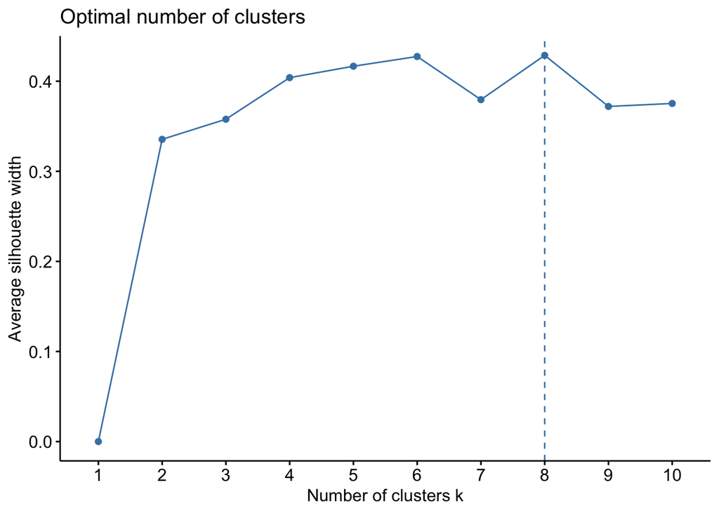

```r
fviz_nbclust(data_mall_standardize, FUNcluster = kmeans, method = "silhouette")
```

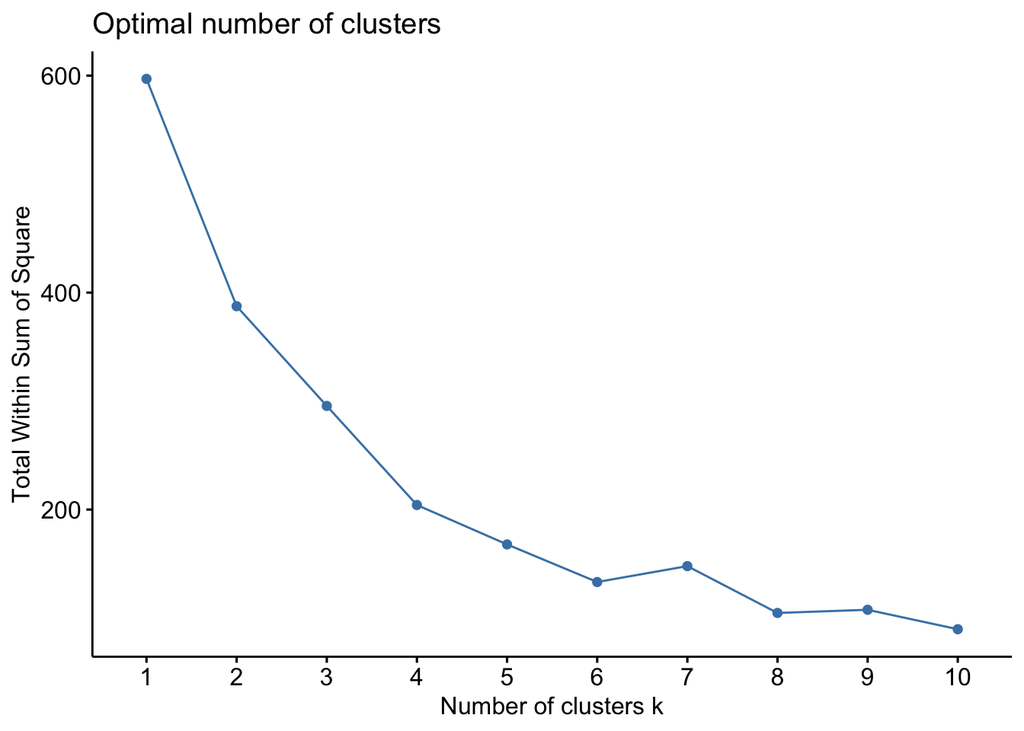

```r
fviz_nbclust(data_mall_standardize, FUNcluster = kmeans, method = "wss")
```

Untuk kriteria koefisien *silhouette*, banyaknya gerombol dengan **nilai koefisien tertinggi** yang kita pilih. Sedangkan pada WSS, banyaknya gerombol yang kita pilih didasarkan pada banyaknya gerombol yang mana garisnya **berbentuk seperti siku (*elbow*)**. Pada gambar diatas garis membentuk siku saat berada di gerombol keempat. **Karena penentuan ini berdasarkan visual, jadi setiap orang mungkin berbeda melihat pola sikunya.**

Berdasarkan kedua kriteria tersebut, banyaknya gerombol terbaik yang dipilih berbeda. Jika demikian, banyaknya gerombol bisa ditentukan berdasarkan kemudahan interpretasi gerombol yang terbentuk. Pada tulisan ini kita akan menggunakan 4 gerombol saja.

[output not shown]

### Menerapkan K-Means

Setelah kita mendapatkan banyaknya gerombol terbaik, maka selajutnya kita akan menerapkan metode K-Means untuk mendapatkan label gerombol pada setiap amatan. Fungsi eclust dari *package* `factoextra` digunakan untuk menerpkan metode K-Means. Pada fungsi `eclust()`, kita cukup memasukan data yang sebelum distandardisasi, karena dalam fungsi tersebut terdapat argumen `stand`, yang jika diatur `stand = TRUE` secara otomatis data yang kita gunakan akan distandardisasi.

```r
kmeans_mall <- eclust(data_mall, stand = TRUE, FUNcluster = "kmeans", k=4, graph = F)
```

Memanggil label gerombol untuk setiap amatan dilakukan dengan:

```r
kmeans_mall$cluster
```

```
##   [1] 3 3 3 3 3 3 2 3 2 3 2 3 2 3 2 3 3 3 2 3 3 3 2 3 2 3 2 3 2 3 2 3 2 3 2 3 2
##  [38] 3 2 3 2 3 2 3 2 3 2 3 3 3 2 3 3 2 2 2 2 2 3 2 2 3 2 2 2 3 2 2 3 3 2 2 2 2
##  [75] 2 3 2 2 3 2 2 3 2 2 3 2 2 3 3 2 2 3 2 2 3 3 2 3 2 3 3 2 2 3 2 3 2 2 2 2 2
## [112] 3 1 3 3 3 2 2 2 2 3 1 4 4 1 4 1 4 2 4 1 4 1 4 1 4 1 4 1 4 1 4 1 4 1 4 1 4
## [149] 1 4 1 4 1 4 1 4 1 4 1 4 2 4 1 4 1 4 1 4 1 4 1 4 1 4 1 4 1 4 1 4 1 4 1 4 1
## [186] 4 1 4 1 4 1 4 1 4 1 4 1 4 1 4
```

Kemu- dian,interpretasi setiap gerombol yang terbentuk dapat dilakukan dengan menggunakan bantuan nilai rata-rata dari masing-masing peubah dihitung berdasarkan gerombol. Informasi ini bisa diperoleh dengan menggunakan `$centers`. Karena kita melakukan standardisasi peubah, maka nilai rata-rata yang diperoleh juga dalam skala standardisasi.

```r
kmeans_mall$centers
```

```
##           Age Annual.Income Spending.Score
## 1  0.03711223     0.9876366     -1.1857814
## 2  1.08344244    -0.4893373     -0.3961802
## 3 -0.96008279    -0.7827991      0.3910484
## 4 -0.42773261     0.9724070      1.2130414
```

### Interpretasi Gerombol yang terbentuk

Berdasarkan nilai rata-rata dari `$centers`, berikut adalah interpretasinya:

Jika sulit membaca hasil dalam bentuk skala standardisasi maka kita bisa menggunakan fungsi `aggregate()` untuk melihat rata-ratanya dalam skala aslinya. Fungsi ini dapat menghitung rata-rata setiap peubah berdasarkan gerombol yang terbentuk.

```r
aggregate(data_mall, by =list(gerombol = kmeans_mall$cluster), FUN = mean)
```

```
##   gerombol      Age Annual.Income Spending.Score
## 1        1 39.36842      86.50000       19.57895
## 2        2 53.98462      47.70769       39.96923
## 3        3 25.43860      40.00000       60.29825
## 4        4 32.87500      86.10000       81.52500
```

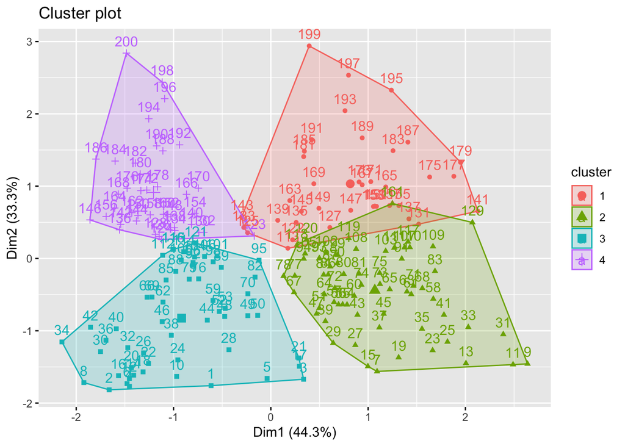

```r
fviz_cluster(kmeans_mall)
```

Cara lain untuk menginterpretasikan hasil gerombol adalah menggunakan scatterplot. Jika peubah untuk membangun cluster lebih dari dua, maka sebelum dibentuk *scatterplot* peubah tersebut direduksi terlebih dahulu menggunakan analisis komponen utama menjadi dua komponen utama. Namun, untuk interpretasinya setiap gerombolnya kita harus mengetahui interpretasi dari kedua komponen utama dan belum tentu dengan dua komponen utama tersebut sudah mampu menjelaskan keragaman data asal dengan baik.

Interpretasi dua komponen utama bisa dilihat dengan akar cirinya.

```r
pca_mall <- prcomp(data_mall_standardize)
pca_mall$rotation
```

```
##                        PC1         PC2          PC3
## Age             0.70638235  0.03014116 -0.707188441
## Annual.Income  -0.04802398  0.99883160 -0.005397916
## Spending.Score -0.70619946 -0.03777499 -0.707004506
```

## *Hierarchical Clustering*

*Hierarchical clustering* menghasilkan hierarki yang dapat dilihat dalam bentuk dendrogram. Dendrogram ini menunjukkan cara objek-objek tersebut dikelompokkan dalam kelompok-kelompok yang berjenjang, dan dapat dipilih sejauh mana tingkat hierarki yang ingin dieksplorasi dengan memotong dendrogram pada tingkat yang sesuai.

Dua jenis *hierarchical clustering*:

- **Agglomerative Clustering** : Dalam metode *agglomerative*, proses dimulai dengan menganggap setiap objek sebagai kelompok tunggal, dan kemudian objek-objek tersebut bergabung dalam kelompok yang semakin besar berdasarkan kesamaan mereka.
- **Divisive Clustering** : Dalam metode *divisive*, proses dimulai dengan menganggap semua objek sebagai satu kelompok besar, dan kemudian kelompok ini dibagi menjadi kelompok yang semakin kecil berdasarkan perbedaan antara objek-objeknya.

Pemilihan jenis *linkage* (cara mengukur jarak antara kelompok) dalam *hierarchical clustering* adalah keputusan penting dalam analisis gerombol ini. *Linkage* mempengaruhi bagaimana kelompok-kelompok dibentuk dan hierarki yang dihasilkan dalam dendrogram. Beberapa jenis *linkage* antara lain:

1. *Single linkage* (berdasarkan jarak terdekat antara anggota kelompok)
2. *Complete linkage* (berdasarkan jarak terjauh antara anggota kelompok)
3. *Average linkage* (berdasarkan jarak rataan antara anggota kelompok)
4. *Ward’s Method* (berdasarkan variansi dalam anggota kelompok)
5. *Centroid Linkage* (berdasarkan centroid antara anggota kelompok)

Tahap analisis gerombol dengan *hierarchical clustering*: 1. *Pre-processing* data 2. Memilih metode *linkage* dan banyaknya gerombol 3. Menerapkan *Hierarchical Clustering* 4. Interprestasi gerombol yang terbentuk

## Contoh Kasus

Contoh kasus yang digunakan adalah kasus yang sama dengan contoh sebelumnya, dengan data yang dipakai adalah data numerik yang distandardisasi sebagaimana data pada contoh sebelumnya.

```r
head(data_mall_standardize)
```

```
##             Age Annual.Income Spending.Score
## [1,] -1.4210029     -1.734646     -0.4337131
## [2,] -1.2778288     -1.734646      1.1927111
## [3,] -1.3494159     -1.696572     -1.7116178
## [4,] -1.1346547     -1.696572      1.0378135
## [5,] -0.5619583     -1.658498     -0.3949887
## [6,] -1.2062418     -1.658498      0.9990891
```

### Memilih Metode *Linkage* Banyaknya Gerombol

Untuk memilih metode linkage dan banyaknya gerombol bisa menggunakan

1. Koefisien *silhoutte* dan WSS (seperti K-Means)
2. Menggunakan dendogram

##### Menggunakan koefisien *silhouette* dan WSS

Untuk ilustrasi kita akan menggunakan metode *silhouette* saja karena lebih mudah menentukan jumlah gerombolnya.

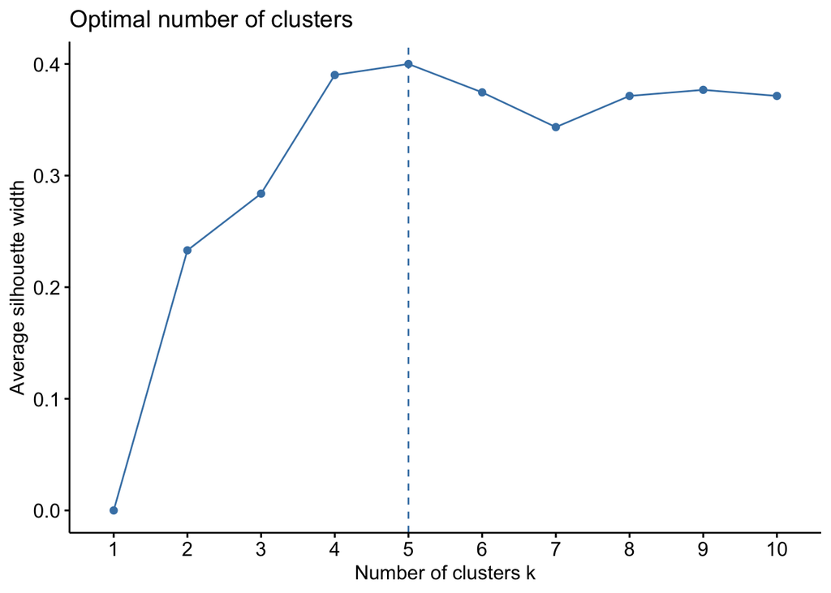

```r
# complete
fviz_nbclust(data_mall_standardize, FUNcluster = hcut, method = "silhouette", hc_method = "complete", hc_metric = "euclidean")
```

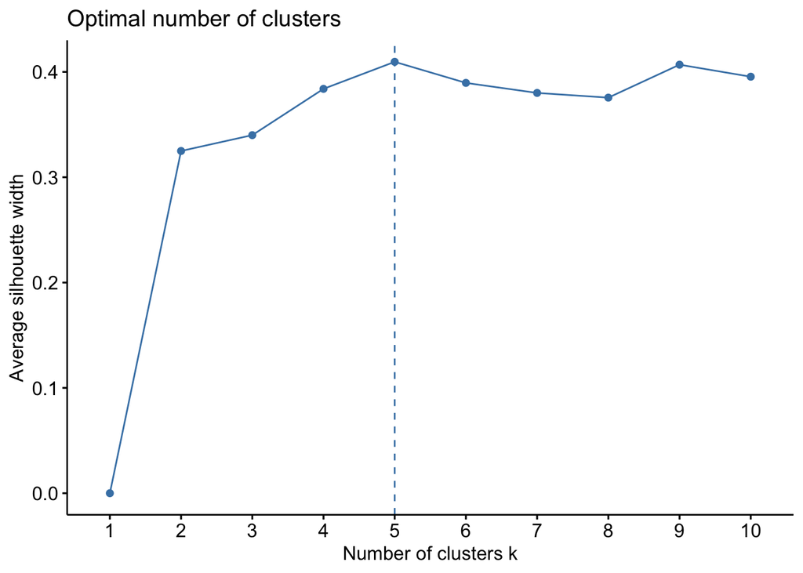

```r
# average
fviz_nbclust(data_mall_standardize, FUNcluster = hcut, method = "silhouette", hc_method = "average", hc_metric = "euclidean")
```

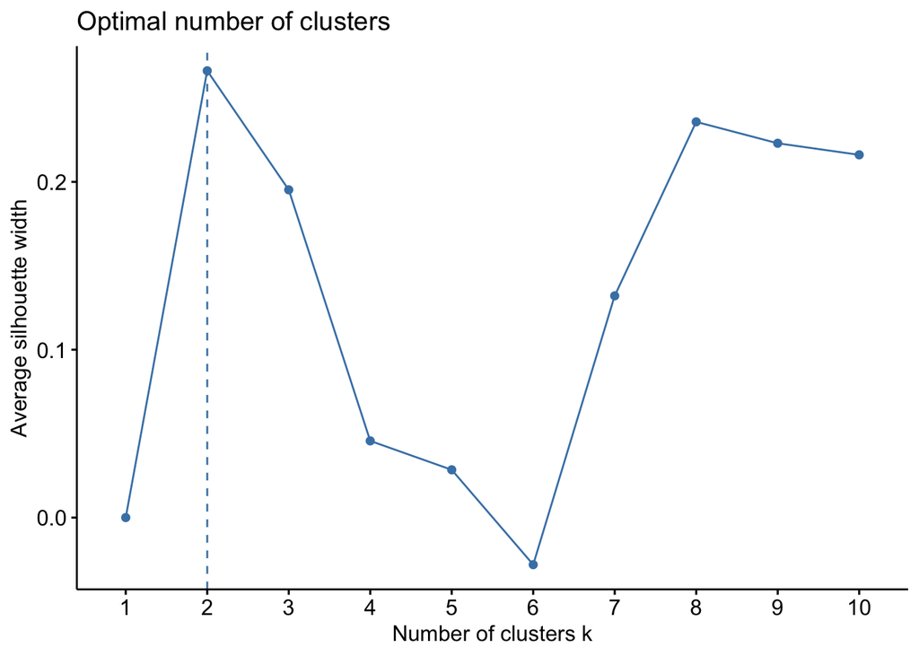

```r
# centroid
fviz_nbclust(data_mall_standardize, FUNcluster = hcut, method = "silhouette", hc_method = "centroid", hc_metric = "euclidean")
```

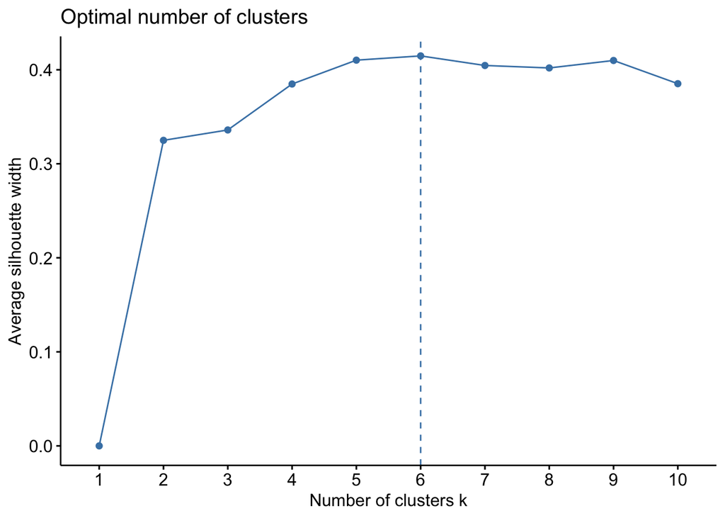

```r
# ward
fviz_nbclust(data_mall_standardize, FUNcluster = hcut, method = "silhouette", hc_method = "ward.D", hc_metric = "euclidean")
```

Berdasarkan koefisien *silhouette*, metode *complete* dan *average* memilih 5 gerombol, sedangkan metode *centroid* dan *ward* masing-masing memilih 2 dan 6 gerombol. Untuk saat ini, kita akan mencoba menggunakan 5 gerombol dengan metode *complete* (Jika dua metode *linkage* memilih banyaknya gerombol yang sama, gerombol yang terbentuk akan relatif mirip, oleh karena itu bisa pilih salah satu).

##### Menggunakan dendogram

Penggunaan dendogram untuk data yang memiliki amatan yang banyak mungkin tidak efektif karena memilih gerombol dengan dendogram dilakukan secara visual.

```r
linkage_methods <- c("complete", "average", "centroid", "ward.D")
hc_mall_dend <- lapply(linkage_methods, function(i)
    hclust(dist(data_mall_standardize, method = 'euclidean'), method = i)
    )
```

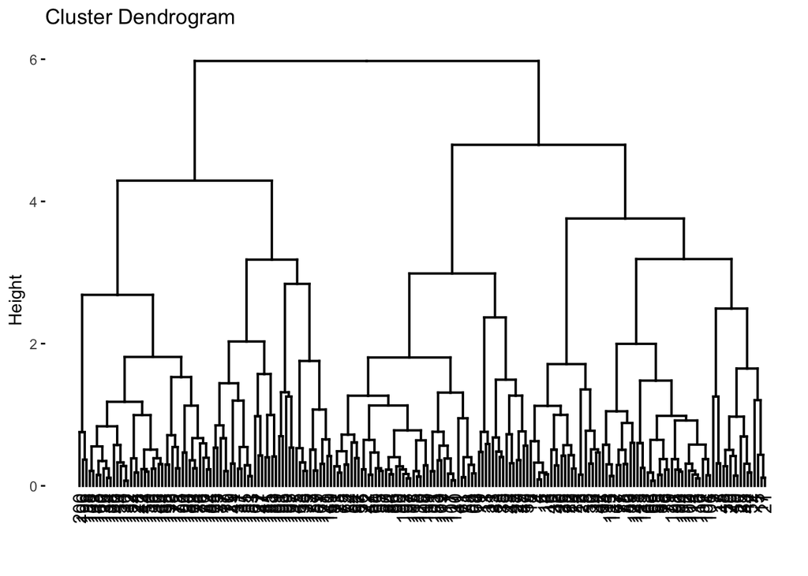

```r
# complete
fviz_dend(hc_mall_dend[[1]])
```

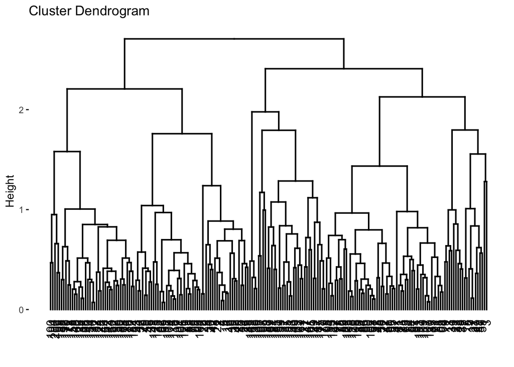

```r
# average
fviz_dend(hc_mall_dend[[2]])
```

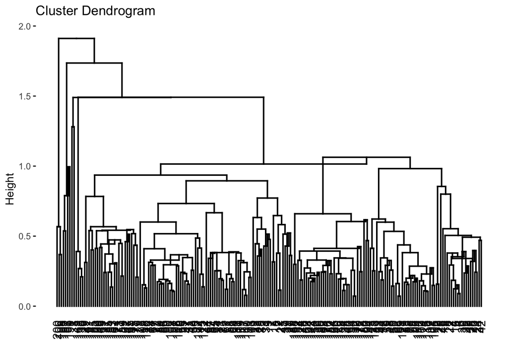

```r
# centroid
fviz_dend(hc_mall_dend[[3]])
```

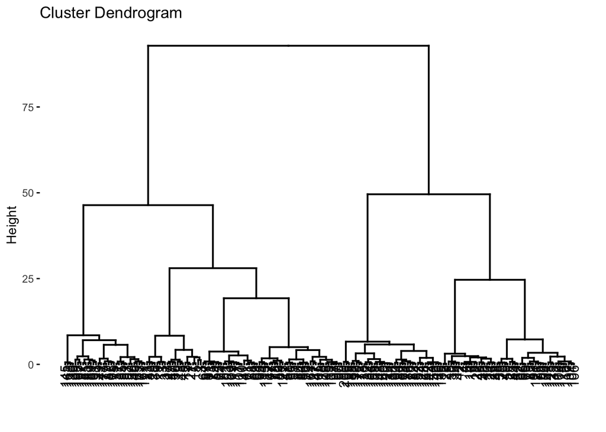

```r
# ward
fviz_dend(hc_mall_dend[[4]])
```

Jika diperhatikan dari keempat dendogram pada masing-masing metode *linkage*, banyaknya gerombol yang terbentuk sama seperti menggunakan keofisien *silhouette* diatas.

### Menerapkan *Hierarchical Clustering*

```r
hc_mall <- eclust(data_mall,stand = TRUE,FUNcluster = "hclust", k=5, hc_method = "complete", hc_metric = "euclidean")
hc_mall$cluster
```

```
##   [1] 1 2 1 2 1 2 1 2 3 2 3 2 3 2 1 2 1 2 3 2 1 2 3 2 3 2 3 1 3 2 3 2 3 2 3 2 3
##  [38] 2 3 2 3 2 3 1 3 2 3 1 1 1 3 1 1 3 3 3 3 3 1 3 3 1 3 3 3 1 1 3 1 1 3 3 3 3
##  [75] 3 1 1 1 1 3 3 1 3 3 1 3 3 1 1 3 3 1 3 1 1 1 3 1 3 1 1 3 3 1 3 1 3 3 3 3 3
## [112] 1 1 1 1 1 3 3 3 3 1 1 1 4 1 4 5 4 5 4 5 4 1 4 5 4 5 4 5 4 5 4 1 4 5 4 5 4
## [149] 5 4 5 4 5 4 5 4 5 4 5 4 5 4 5 4 5 4 5 4 5 4 5 4 5 4 5 4 5 4 5 4 5 4 5 4 5
## [186] 4 5 4 5 4 5 4 5 4 5 4 5 4 5 4
```

### Interprestasi Gerombol yang terbentuk

Coba lakukan interpretasi gerombol seperti metode kmeans diatas.

```r
aggregate(data_mall,by =list(gerombol=hc_mall$cluster), FUN = mean)
```

```
##   gerombol      Age Annual.Income Spending.Score
## 1        1 28.35417      50.29167       45.93750
## 2        2 24.80952      25.61905       80.23810
## 3        3 55.33333      47.31579       41.08772
## 4        4 32.69231      86.53846       82.12821
## 5        5 41.68571      88.22857       17.28571
```

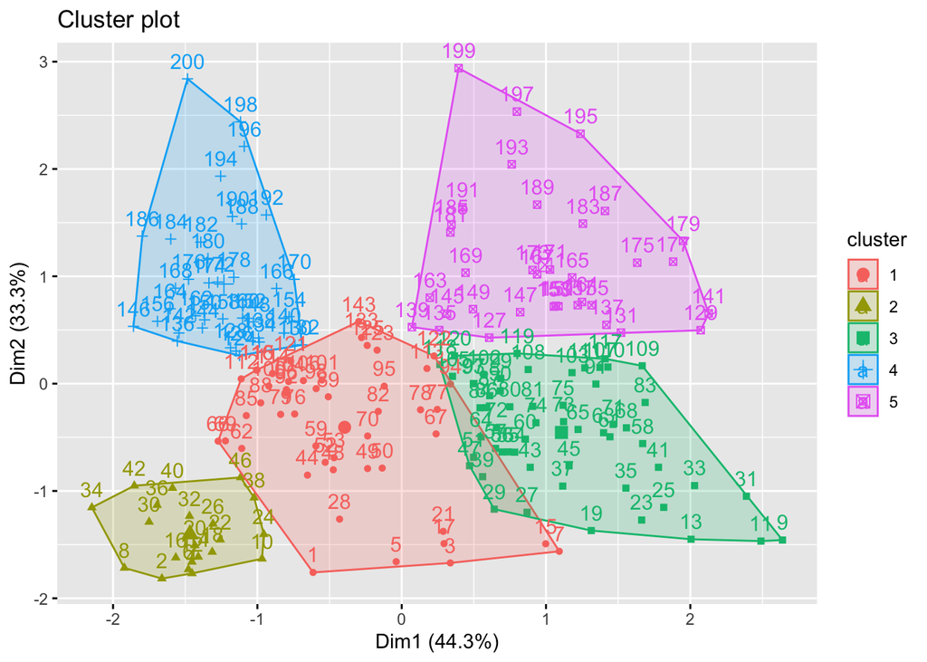

```r
fviz_cluster(hc_mall)
```

Interpretasi dua komponen utama bisa dilihat dengan akar cirinya.

```r
pca_mall <- prcomp(data_mall_standardize)
pca_mall$rotation
```

```
##                        PC1         PC2          PC3
## Age             0.70638235  0.03014116 -0.707188441
## Annual.Income  -0.04802398  0.99883160 -0.005397916
## Spending.Score -0.70619946 -0.03777499 -0.707004506
```